# Modelos de distribuição de espécies em R usando o pacote biomod2

Juliano Palacios Abrantes

Última atualização 2024-11-07

# Objectivo

Nesta sessao, aprenderemos como criar e avaliar modelos de distribuição de espécies (SDMs) usando o pacote `biomod2` em R. Ao final desta sessão, você deverá ser capaz de preparar seus dados, construir um modelo e visualizar os resultados.

# 1. Preparar dados

Para modelagem de distribuição de espécies, você precisará de dois componentes principais:

- Dados de Espécies (Presença-Ausência ou Contagens): Normalmente é um quadro de dados ou um conjunto de pontos com ocorrências de espécies (latitude, longitude) e as observações correspondentes (presença ou ausência).
- Dados Ambientais (Preditores): Conjunto de variáveis ambientais (e.g., temperatura, precipitação) que ajudam a modelar a distribuição das espécies. Geralmente são camadas rasterizadas.

## Preparar dados ambientais

Você precisará de camadas ambientais para a região de interesse. Normalmente são camadas raster, que você pode carregar usando o pacote raster. Essas camadas podem ser dados climáticos (temperatura, precipitação, etc.), cobertura do solo, elevação, etc.

```r
# Carregar dados ambientais

# Lista de rasters individuais
raster_path <- list.files("../03_dados/02_variaveis/",full.names = T)[-7]

# Por que usamos o "[-7]"?
raster_path
```

```
[1] "../03_dados/02_variaveis//bio15.tif" "../03_dados/02_variaveis//bio18.tif" "../03_dados/02_variaveis//bio19.tif"
[4] "../03_dados/02_variaveis//bio2.tif"  "../03_dados/02_variaveis//bio3.tif"  "../03_dados/02_variaveis//bio8.tif"
```

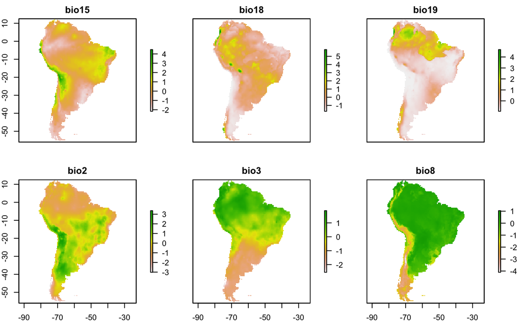

```r
# Carrega todos os rasters juntos
env_data <- stack(raster_path)

# Vamos ver
plot(env_data)
```

```r
NA
NA
```

## Preparar dados de ocorrencia

Prepare seus dados de ocorrência de espécies. Você deverá ter a latitude e longitude de cada ponto de ocorrência, bem como uma variável de resposta binária indicando se a espécie está presente ou não.

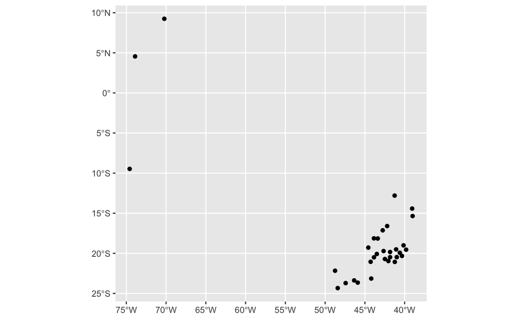

```r
# Carregar os dados de occorrencia

path_sf <- "../03_dados/01_ocorrencias/"

# The File
name_sf <- "occ_data_filter_edit.shp"

# Load it!
occ_sf <- st_read(dsn = path_sf,
                        layer =file_path_sans_ext(name_sf))
### TAMBEM FUNCIONA ASSIM
occ_sf <- st_read("../03_dados/01_ocorrencias/occ_data_filter_edit.shp")
# Seleccionar occ
occ_data <- as.data.frame(occ_sf) %>%
  select(sptdst_,longitd,latitud)

# extrair coordenadas
coordinates(occ_data) <- ~longitd + latitud


#Visualizar dados
ggplot(occ_sf) +
  geom_sf()
```

## 2. Construçao do modelo

### Opções globais do modelo (`BIOMOD_Modeling`)

Esta seção seleciona as diferentes opções que queremos incluir em nosso modelo.

- *mds_algo*, observe que cada algoritmo tem suas próprias opções e configurações específicas para usuários mais avançados
- *n_rep*, Quanto mais dados, mais repetições, até certo ponto (por exemplo, 5-6 repetições). Duas já sao boas, mas pode ficar confuso. 10 é extremamente bom mas muitos dados a serem analizados.
- *data_sample*, representa a porcentagem de dados que você deseja usar para treinar o modelo.
- *eval_metric*, voce pode utilizar *ROC*, *TSS*, ou ambas
- *model_thresh*, Determina o limite para seleção de “bons” modelos. Em geral, qualquer valor acima de 0,7 e bem recebido. Está relacionado ao `eval_metric`, enato precisa de um valor para cada metrica

```r
# Escolha os algoritmos a ser usados
mds_algo <- c('GLM','GAM',"ANN","RF")
# Número de repetições
n_rep <- 3 # Número de repetições que desejo (seleção aleatória de variáveis)

# Porcentagem de dados para amostra
data_sample <- 70

# Métrica de avaliação
eval_metric <- c("ROC","TSS")

# Opções globais BIOMOD_EnsembleModeling

# Limite de inclusão do modelo
model_thresh <- c(0.5,0.5)
```

### Estrutura e opções do modelo

Para construir o modelo, primeiro precisamos criar um objeto biomod2 usando a função BIOMOD_FormatingData. Esta função prepara os dados de espécies e dados ambientais para modelagem.

```r
biomod_data <- BIOMOD_FormatingData(
  resp.var = occ_data,
  expl.var = env_data,
  resp.xy = coords,
  resp.name = "marmosops_incanus",
  PA.nb.rep = 3, # NUmber of batch pseudo absent (at least 3)
  PA.strategy = 'random'
)
```

### Execução do modelo

Agora que os dados estão preparados, você pode executar vários modelos de distribuição de espécies usando o BIOMOD2. Suporta múltiplas técnicas de modelagem, incluindo MaxEnt, Random Forest, GLM e muito mais.

```r
# Criar nosso modelo
biomod_model <- BIOMOD_Modeling(
  bm.format = biomod_data,
  models = mds_algo,
  CV.strategy = "random",
  CV.perc = 0.7,
  CV.nb.rep = 2,
  metric.eval = c('TSS','ROC')
)
```

# Explore response curves

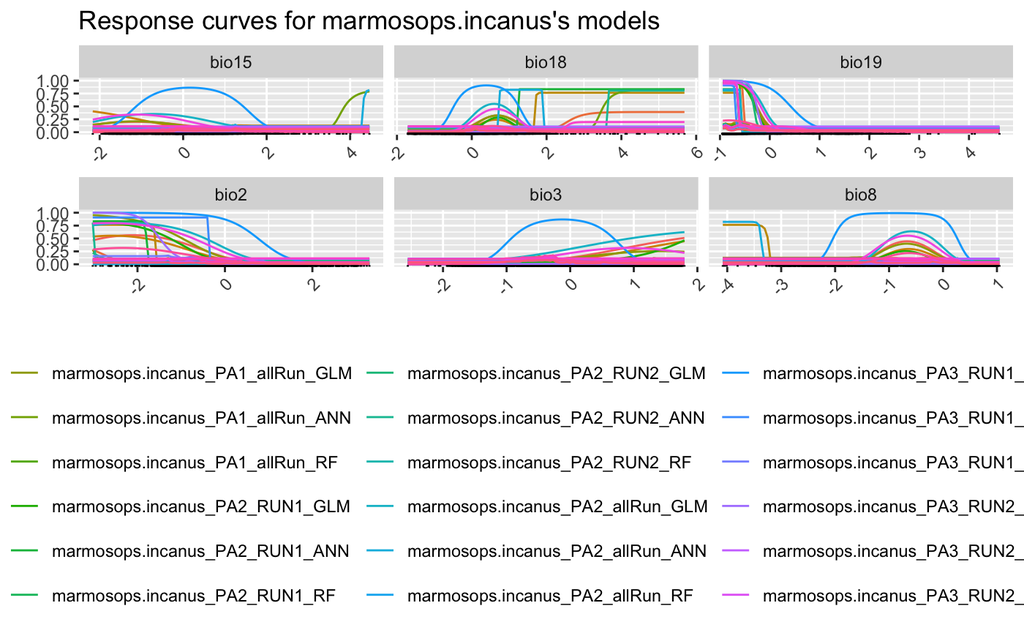

```r
# Plot response curve
env_window <- bm_PlotResponseCurves(
  biomod_model,
  fixed.var = 'mean')
```

Sao tantos modelos que nao da pra entender nada, enao vamos fazer um pomedio dos melhores modelos

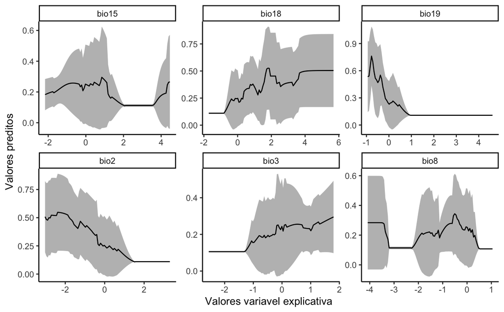

# Avaliações de modelo

Depois de executar os modelos, você pode avaliar seu desempenho usando diversas métricas de avaliação (por exemplo, AUC, TOC, etc.). biomod2 fornece automaticamente métricas de validação cruzada.

|  | full.name | PA | run | algo | metric.eval | cutoff | sensitivity | specificity | calibration | validation | evaluation |
| --- | --- | --- | --- | --- | --- | --- | --- | --- | --- | --- | --- |
| 1 | marmosops.incanus_PA1_RUN1_GLM | PA1 | RUN1 | GLM | TSS | 362.0 | 100.000 | 83.125 | 0.831 | 0.835 | NA |
| 2 | marmosops.incanus_PA1_RUN1_GLM | PA1 | RUN1 | GLM | ROC | 361.5 | 100.000 | 83.125 | 0.955 | 0.946 | NA |
| 3 | marmosops.incanus_PA1_RUN1_ANN | PA1 | RUN1 | ANN | TSS | 661.0 | 95.455 | 95.250 | 0.907 | 0.515 | NA |
| 4 | marmosops.incanus_PA1_RUN1_ANN | PA1 | RUN1 | ANN | ROC | 660.5 | 95.455 | 95.250 | 0.964 | 0.832 | NA |
| 5 | marmosops.incanus_PA1_RUN1_RF | PA1 | RUN1 | RF | TSS | 443.0 | 100.000 | 100.000 | 1.000 | -0.010 | NA |
| 6 | marmosops.incanus_PA1_RUN1_RF | PA1 | RUN1 | RF | ROC | 442.0 | 100.000 | 100.000 | 1.000 | 0.947 | NA |
| 7 | marmosops.incanus_PA1_RUN2_GLM | PA1 | RUN2 | GLM | TSS | 382.0 | 100.000 | 83.250 | 0.833 | 0.860 | NA |
| 8 | marmosops.incanus_PA1_RUN2_GLM | PA1 | RUN2 | GLM | ROC | 383.0 | 100.000 | 83.250 | 0.953 | 0.952 | NA |
| 9 | marmosops.incanus_PA1_RUN2_ANN | PA1 | RUN2 | ANN | TSS | 574.0 | 100.000 | 72.125 | 0.721 | 0.740 | NA |
| 10 | marmosops.incanus_PA1_RUN2_ANN | PA1 | RUN2 | ANN | ROC | 574.0 | 100.000 | 72.125 | 0.860 | 0.885 | NA |

[output cut: 48 more lines]

## Plot de ROC and TSS

| name | mean1 | mean2 | sd1 | sd2 |
| --- | --- | --- | --- | --- |
| ANN | 0.9152222 | 0.8237778 | 0.04053325 | 0.06504763 |
| GLM | 0.9602000 | 0.8573000 | 0.01233604 | 0.04143549 |
| RF | 1.0000000 | 1.0000000 | 0.00000000 | 0.00000000 |

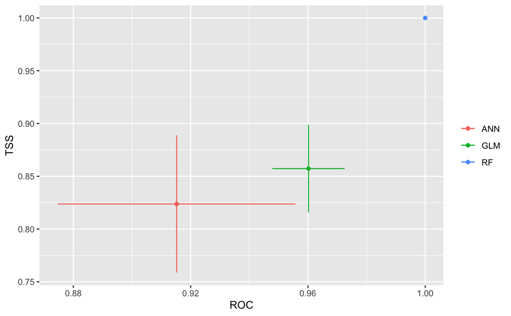

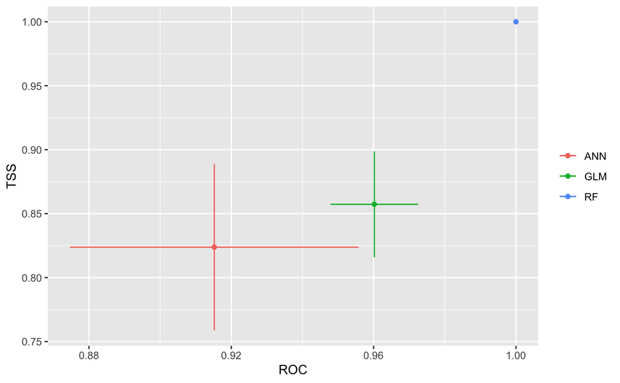

```r
# Fazer figura TSS vs ROC
bm_PlotEvalMean(biomod_model)
```